# 11 — Veteran Success Profile

PGA Tour Distance & Speed Analytics

2026-07-08

# Overview

**Question:** Project 10’s Section 3 found the 40+ share of the tour’s top 100 collapsed from roughly 31% to 8% since 2004. That tells us *how many* veterans remain competitive, but not *what changed about them*. This notebook asks: is the profile of a successful 40+ golfer different today than it was two decades ago, and what actually separates the 40+ golfers who are still competitive from those who aren’t?

**Data:** `df_main`, filtered to `age >= 40`. A comprehensive set of available metrics is used: driving distance and accuracy relative to the field (`dist_vs_field`, `acc_vs_field`), swing-speed metrics available from `SPEED_ERA_START` onward (`speed_vs_field`, `chs_vs_field`), and all four Strokes Gained components plus the total (`sg_ott`, `sg_apr`, `sg_arg`, `sg_putt`, `sg_total`).

**A genuine data limitation, checked and confirmed rather than assumed:** there is no greens-in-regulation (GIR) column anywhere in this project — not in `df_complete.csv`, not in `trends_acc_dist_1987_to_2025.csv`, and not among `df_main`’s engineered columns. This isn’t a case where another file in the repo can recover it (unlike the `entry_year` fix in `00_data_engineering.Rmd`) — it’s a real boundary of the source data. Accuracy (fairways hit %) and the four SG components stand in as the best available substitutes for shot-making quality.

**“Successful 40+” is defined as tour-wide top-100 by `sg_total` that year** — the same population `10_key_visuals.Rmd` Section 3 used, so this notebook stays directly tied to the finding that motivated it.

**Two eras for comparison**, reusing the Early/Late split from Projects 5 and 7: **Early (2004-2010)** vs. **Late (2018-2025)**. Speed metrics (`speed_vs_field`, `chs_vs_field`) are only reliable from 2007 onward (`SPEED_ERA_START`), so any comparison involving them uses **Early (2007-2010)** instead — the same `speed_era_only` handling Project 6 used for this exact reason.

# Setup

```r
library(tidyverse)
library(here)
library(patchwork)
library(scales)

source(here::here("config.R"))
source(here::here("R", "coord_radar.R"))

df_main <- readRDS(here(PATH_PROCESSED, "df_main.rds")) %>%
  filter(player_name != "Patrick Sheehan")

knitr::opts_chunk$set(
  echo    = TRUE,
  message = FALSE,
  warning = FALSE,
  fig.width  = 10,
  fig.height = 7
)
```

# 1. The 40+ Population

```r
df_40 <- df_main %>% filter(age >= 40)

top100_by_year <- df_main %>%
  group_by(year) %>%
  slice_max(sg_total, n = 100) %>%
  ungroup() %>%
  select(player_name, year, top100 = sg_total) %>%
  mutate(top100 = TRUE)

df_40 <- df_40 %>%
  left_join(top100_by_year, by = c("player_name", "year")) %>%
  mutate(top100 = coalesce(top100, FALSE))

pop_by_year <- df_40 %>%
  group_by(year) %>%
  summarise(n_40plus = n(), n_successful = sum(top100), .groups = "drop")

pop_by_year %>% print(n = 22)
```

```
## # A tibble: 22 x 3
##     year n_40plus n_successful
##    <int>    <int>        <int>
##  1  2004       61           32
##  2  2005       63           35
##  3  2006       58           28
##  4  2007       50           22
##  5  2008       56           26
##  6  2009       49           24
##  7  2010       55           23
##  8  2011       46           23
##  9  2012       43           18
## 10  2013       37           19
## 11  2014       34           18
## 12  2015       35           12
## 13  2016       36           16
## 14  2017       37           16
## 15  2018       33           19
## 16  2019       32           18
## 17  2020       38           17
## 18  2021       41           21
## 19  2022       35           14
## 20  2023       30            9
## 21  2024       22            8
## 22  2025       15            7
```

**Finding:** the 40+ population itself has shrunk from 61 (2004) to 15 (2025) player-seasons, and the number of those also in the tour-wide top 100 fell from 32 to 7. The most recent years (2023-2025) have as few as 7 successful 40+ player-seasons — any year-by-year read of that tail should be treated as illustrative, not a stable estimate.

# 2. Has the General 40+ Profile Shifted?

Before narrowing to who’s still winning, has the *average* 40-something tour player changed at all? MANOVA + radar comparison, reusing the exact pattern from `05_player_archetypes.Rmd` Section 6, applied here to *all* 40+ player-seasons (not just successful ones).

```r
core_vars  <- c("dist_vs_field", "acc_vs_field", "sg_ott", "sg_apr", "sg_arg", "sg_putt", "sg_total")
speed_vars <- c("speed_vs_field", "chs_vs_field")

early_40 <- df_40 %>% filter(year >= 2004, year <= 2010) %>% mutate(era_grp = "Early (2004-2010)")
late_40  <- df_40 %>% filter(year >= 2018, year <= 2025) %>% mutate(era_grp = "Late (2018-2025)")
combined_40 <- bind_rows(early_40, late_40)

cat("n early:", nrow(early_40), " n late:", nrow(late_40), "\n")
```

```
## n early: 392  n late: 246
```

## 2.1 Core Profile (Distance, Accuracy, Strokes Gained)

```r
Y_core <- as.matrix(combined_40 %>% select(all_of(core_vars)))
fit_core <- manova(Y_core ~ era_grp, data = combined_40)
summary(fit_core, test = "Pillai")
```

```
##            Df   Pillai approx F num Df den Df Pr(>F)
## era_grp     1 0.016039    1.467      7    630 0.1761
## Residuals 636
```

```r
profile_core <- combined_40 %>%
  group_by(era_grp) %>%
  summarise(across(all_of(core_vars), mean), .groups = "drop")

profile_core %>% print()
```

```
## # A tibble: 2 x 8
##   era_grp      dist_vs_field acc_vs_field  sg_ott sg_apr sg_arg sg_putt sg_total
##   <chr>                <dbl>        <dbl>   <dbl>  <dbl>  <dbl>   <dbl>    <dbl>
## 1 Early (2004~         -4.06         1.89 -0.0306 0.117  0.0363 -0.0211   0.101
## 2 Late (2018-~         -4.94         1.62 -0.0830 0.0548 0.0533 -0.0460  -0.0209
```

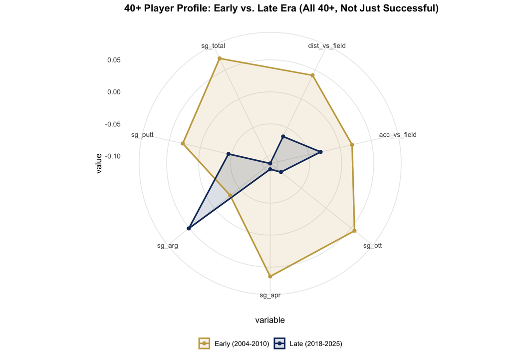

```r
combined_40_z <- combined_40 %>%
  mutate(across(all_of(core_vars), ~as.numeric(scale(.x)), .names = "z_{.col}"))

radar_core <- combined_40_z %>%
  group_by(era_grp) %>%
  summarise(across(starts_with("z_"), mean), .groups = "drop") %>%
  pivot_longer(-era_grp, names_to = "variable", values_to = "value") %>%
  mutate(variable = str_remove(variable, "^z_"))

radar_core_closed <- radar_core %>%
  group_by(era_grp) %>%
  group_modify(~bind_rows(.x, .x[1, ])) %>%
  ungroup() %>%
  mutate(variable = factor(variable, levels = unique(variable)))

p_radar_core <- ggplot(radar_core_closed, aes(x = variable, y = value, group = era_grp, color = era_grp)) +
  geom_polygon(aes(fill = era_grp), alpha = 0.15, linewidth = 1) +
  geom_line(linewidth = 1) +
  geom_point(size = 2) +
  scale_color_manual(values = c("Early (2004-2010)" = COL_SECONDARY, "Late (2018-2025)" = COL_PRIMARY)) +
  scale_fill_manual(values = c("Early (2004-2010)" = COL_SECONDARY, "Late (2018-2025)" = COL_PRIMARY)) +
  coord_radar() +
  labs(title = "40+ Player Profile: Early vs. Late Era (All 40+, Not Just Successful)", color = NULL, fill = NULL) +
  THEME_BASE

p_radar_core
```

```r
p_core <- summary(fit_core, test = "Pillai")$stats["era_grp", "Pr(>F)"]
dist_early <- profile_core$dist_vs_field[profile_core$era_grp == "Early (2004-2010)"]
dist_late  <- profile_core$dist_vs_field[profile_core$era_grp == "Late (2018-2025)"]
sgtot_early <- profile_core$sg_total[profile_core$era_grp == "Early (2004-2010)"]
sgtot_late  <- profile_core$sg_total[profile_core$era_grp == "Late (2018-2025)"]
```

**Finding:** the MANOVA is not significant (Pillai’s trace, p = 0.176) — across all seven core metrics jointly, the *general* 40+ population’s profile has **not** shifted at a statistically detectable level. This is worth stating plainly rather than smoothing over: `sg_total` did drop on average (0.101 to -0.021), and `dist_vs_field` moved from -4.06 to -4.94 yards relative to the field, but neither this nor the other five metrics moves far enough, relative to the noise in a population of this size, to call the *whole* 40+ population’s game different. The radar chart shows the direction of each individual shift, but the honest read of this section is that **the story is likely about composition (who’s still on tour at 40+) rather than a broad change in how 40+ players play** — which is exactly what Section 3 investigates directly.

## 2.2 Speed Profile (Speed Era Only)

```r
early_40_speed <- df_40 %>% filter(year >= 2007, year <= 2010) %>% mutate(era_grp = "Early (2007-2010)")
late_40_speed  <- df_40 %>% filter(year >= 2018, year <= 2025) %>% mutate(era_grp = "Late (2018-2025)")
combined_40_speed <- bind_rows(early_40_speed, late_40_speed)

cat("n early (speed era):", nrow(early_40_speed), " n late:", nrow(late_40_speed), "\n")
```

```
## n early (speed era): 210  n late: 246
```

```r
Y_speed <- as.matrix(combined_40_speed %>% select(all_of(speed_vars)))
fit_speed <- manova(Y_speed ~ era_grp, data = combined_40_speed)
summary(fit_speed, test = "Pillai")
```

```
##            Df    Pillai approx F num Df den Df Pr(>F)
## era_grp     1 0.0025388   0.5765      2    453 0.5623
## Residuals 454
```

```r
profile_speed <- combined_40_speed %>%
  group_by(era_grp) %>%
  summarise(across(all_of(speed_vars), mean), .groups = "drop")

profile_speed %>% print()
```

```
## # A tibble: 2 x 3
##   era_grp           speed_vs_field chs_vs_field
##   <chr>                      <dbl>        <dbl>
## 1 Early (2007-2010)          -2.90        -1.93
## 2 Late (2018-2025)           -3.26        -2.24
```

```r
p_speed <- summary(fit_speed, test = "Pillai")$stats["era_grp", "Pr(>F)"]
bs_early <- profile_speed$speed_vs_field[profile_speed$era_grp == "Early (2007-2010)"]
bs_late  <- profile_speed$speed_vs_field[profile_speed$era_grp == "Late (2018-2025)"]
```

**Finding:** the speed-only MANOVA is not significant (p = 0.562). Mean ball speed relative to the field moved from -2.9 (2007-2010) to -3.26 mph (2018-2025) — read alongside the core-profile result above, not as an independent claim, since the speed-era window truncates the early period by three years.

# 3. What Separates Successful 40+ From the Rest?

The comparison above describes the *average* 40-something, which mixes successful and unsuccessful players together. This section isolates what actually discriminates the two, and whether that discriminator has changed between eras — the direct answer to “what does it take.”

```r
compute_d <- function(data, metric) {
  x <- data[[metric]][data$top100]
  y <- data[[metric]][!data$top100]
  x <- x[!is.na(x)]; y <- y[!is.na(y)]
  pooled_sd <- sqrt(((length(x) - 1) * var(x) + (length(y) - 1) * var(y)) / (length(x) + length(y) - 2))
  tibble(metric = metric, mean_successful = mean(x), mean_rest = mean(y),
         cohens_d = (mean(x) - mean(y)) / pooled_sd, n_successful = length(x), n_rest = length(y))
}

discriminant_core <- map_dfr(core_vars, ~bind_rows(
  compute_d(early_40, .x) %>% mutate(era_grp = "Early (2004-2010)"),
  compute_d(late_40, .x)  %>% mutate(era_grp = "Late (2018-2025)")
))

discriminant_speed <- map_dfr(speed_vars, ~bind_rows(
  compute_d(early_40_speed, .x) %>% mutate(era_grp = "Early (2007-2010)"),
  compute_d(late_40_speed, .x)  %>% mutate(era_grp = "Late (2018-2025)")
))

discriminant_all <- bind_rows(discriminant_core, discriminant_speed)
discriminant_all %>% select(metric, era_grp, cohens_d, n_successful, n_rest) %>% print(n = 30)
```

```
## # A tibble: 18 x 5
##    metric         era_grp           cohens_d n_successful n_rest
##    <chr>          <chr>                <dbl>        <int>  <int>
##  1 dist_vs_field  Early (2004-2010)    0.338          190    202
##  2 dist_vs_field  Late (2018-2025)     0.465          113    133
##  3 acc_vs_field   Early (2004-2010)    0.191          190    202
##  4 acc_vs_field   Late (2018-2025)     0.185          113    133
##  5 sg_ott         Early (2004-2010)    0.904          190    202
##  6 sg_ott         Late (2018-2025)     0.919          113    133
##  7 sg_apr         Early (2004-2010)    1.28           190    202
##  8 sg_apr         Late (2018-2025)     1.02           113    133
##  9 sg_arg         Early (2004-2010)    0.603          190    202
## 10 sg_arg         Late (2018-2025)     0.506          113    133
## 11 sg_putt        Early (2004-2010)    0.696          190    202
## 12 sg_putt        Late (2018-2025)     0.904          113    133
## 13 sg_total       Early (2004-2010)    2.43           190    202
## 14 sg_total       Late (2018-2025)     2.34           113    133
## 15 speed_vs_field Early (2007-2010)    0.397           95    115
## 16 speed_vs_field Late (2018-2025)     0.400          113    133
## 17 chs_vs_field   Early (2007-2010)    0.377           95    115
## 18 chs_vs_field   Late (2018-2025)     0.421          113    133
```

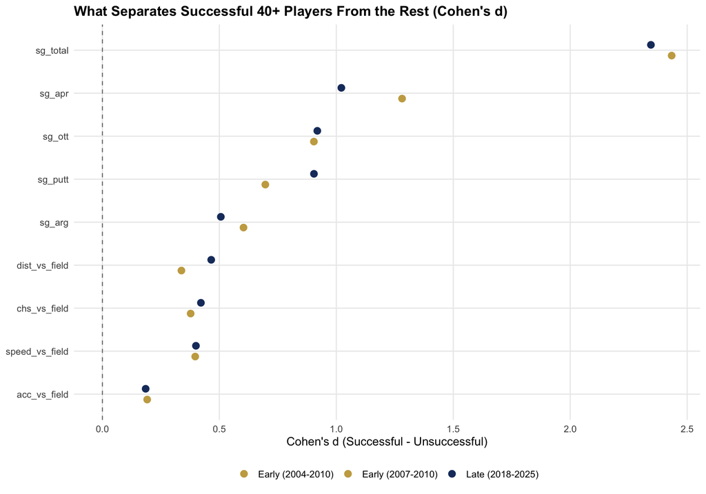

```r
p_discriminant <- ggplot(discriminant_all, aes(x = cohens_d, y = reorder(metric, cohens_d), color = era_grp)) +
  geom_vline(xintercept = 0, linetype = "dashed", color = "grey50") +
  geom_point(size = 3, position = position_dodge(width = 0.5)) +
  scale_color_manual(values = c(
    "Early (2004-2010)" = COL_SECONDARY, "Early (2007-2010)" = COL_SECONDARY,
    "Late (2018-2025)" = COL_PRIMARY
  )) +
  labs(
    title = "What Separates Successful 40+ Players From the Rest (Cohen's d)",
    x = "Cohen's d (Successful - Unsuccessful)", y = NULL, color = NULL
  ) +
  THEME_BASE

p_discriminant
```

```r
rank_early <- discriminant_all %>% filter(era_grp == "Early (2004-2010)") %>% arrange(desc(cohens_d))
rank_late  <- discriminant_all %>% filter(era_grp == "Late (2018-2025)", metric %in% core_vars) %>% arrange(desc(cohens_d))
top_early <- rank_early$metric[1]
top_late  <- rank_late$metric[1]
```

**Finding:** in the early era, sg_total shows the largest gap between successful and unsuccessful 40+ players (Cohen’s d = 2.43); in the late era, sg_total shows the largest gap (d = 2.34). Compare the full ranking in the table and plot above rather than reading a single number in isolation — `sg_total` mechanically has the largest d in both eras since the grouping variable is derived from it; the metrics below `sg_total` in the ranking are the ones that actually discriminate *why* some 40+ players reach that bar and others don’t.

# 4. Trajectory of the Successful 40+ Subset

The two-era snapshots above raise the question of whether any shift was gradual or stepped. This traces the successful-40+ subset’s metrics across the full 2004-2025 span.

```r
successful_40 <- df_40 %>% filter(top100)

trajectory_core <- successful_40 %>%
  group_by(year) %>%
  summarise(across(all_of(core_vars), mean, na.rm = TRUE), n = n(), .groups = "drop") %>%
  pivot_longer(all_of(core_vars), names_to = "metric", values_to = "value")

trajectory_speed <- successful_40 %>%
  filter(year >= SPEED_ERA_START) %>%
  group_by(year) %>%
  summarise(across(all_of(speed_vars), mean, na.rm = TRUE), n = n(), .groups = "drop") %>%
  pivot_longer(all_of(speed_vars), names_to = "metric", values_to = "value")

trajectory_all <- bind_rows(trajectory_core, trajectory_speed) %>%
  mutate(metric = factor(metric, levels = c(core_vars, speed_vars)))
```

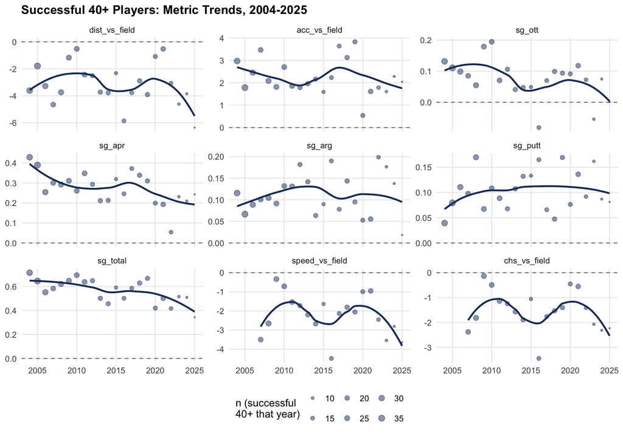

```r
p_trajectory <- ggplot(trajectory_all, aes(year, value)) +
  geom_hline(yintercept = 0, linetype = "dashed", color = "grey50") +
  geom_point(aes(size = n), color = COL_PRIMARY, alpha = 0.5) +
  geom_smooth(method = "loess", se = FALSE, span = 0.75, color = COL_PRIMARY) +
  facet_wrap(~metric, scales = "free_y") +
  scale_size_continuous(name = "n (successful\n40+ that year)", range = c(0.5, 3)) +
  labs(
    title = "Successful 40+ Players: Metric Trends, 2004-2025",
    x = NULL, y = NULL
  ) +
  THEME_BASE

p_trajectory
```

**Finding:** point size scales with the number of successful 40+ players that year — the shrinking points toward 2023-2025 are a visual reminder that the tail of every panel rests on as few as 7 player-seasons and shouldn’t be read as precisely as the earlier, larger-sample years. Read each panel’s overall direction and where (if anywhere) it bends, rather than any single recent-year value.

# 5. Summary